# Spam classification case study

Tamas Koncz

11/17/2021

## Exploratory analysis

We are going to work on the [sms-spam-or-ham](https://www.kaggle.com/dejavu23/sms-spam-or-ham-beginner/data) dataset from Kaggle:

*“The files contain one message per line. Each line is composed by two columns: v1 contains the label (ham or spam) and v2 contains the raw text.”*

The goal is to create the most accurate predictions whether an sms is spam or ham based on the message text.

I recommend to take a look at the raw `.csv` first. Then, we can import it properly to R:

```r
sms <- fread(
    here::here("week10", "data", "spam.csv"),
    header = TRUE,
    select = c("v1", "v2"),
    col.names = c("is_spam", "sms_text"),
    encoding = 'Latin-1'
) %>%
    .[, is_spam := ifelse(is_spam == "spam", 1, 0)]
```

Let’s see the frequency of spam messages in the dataset:

```r
sms %>%
    .[, .N, by = "is_spam"] %>%
    .[, share := scales::percent(N / sum(N), accuracy = 0.01)] %>%
    .[]
```

```
##    is_spam    N  share
## 1:       0 4825 86.59%
## 2:       1  747 13.41%
```

Our dataset is quite imbalanced. We’ll have to pay attention to this when evaluating our models.

### Message length

```r
sms[, sms_chr_length := nchar(sms_text)]
```

```r
sms[, .(avg_sms_chr_length = mean(sms_chr_length)), by = "is_spam"]
```

```
##    is_spam avg_sms_chr_length
## 1:       0           71.04891
## 2:       1          138.86345
```

Okay, this is interesting… let’s dive deeper:

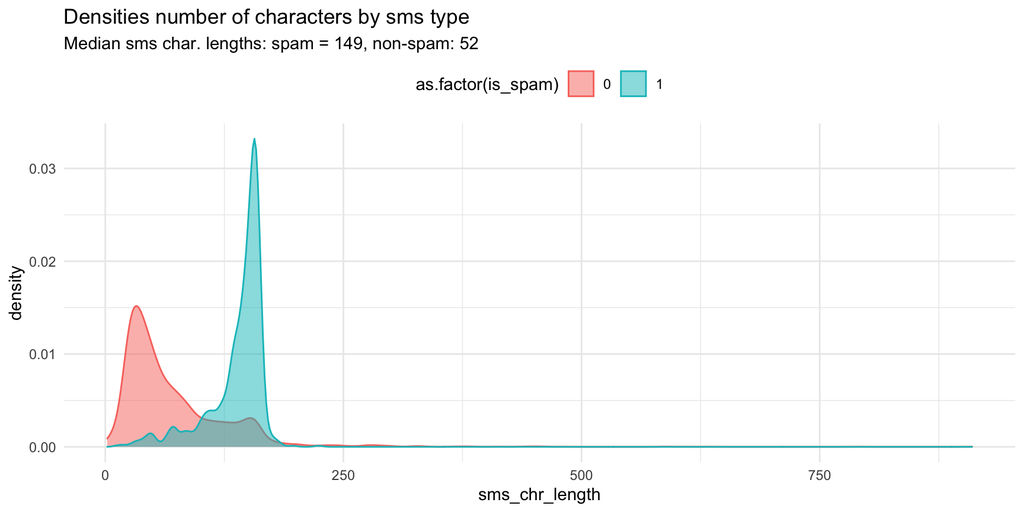

We might have just found our baseline model!

### Tokenization

Add a unique id to each message:

```r
sms[, message_id := 1:.N]
```

Tokenization:

```r
sms_words <- sms %>%
    .[, .(message_id, sms_text)] %>%
    tidytext::unnest_tokens(output = "word", input = "sms_text") %>%
    data.table()
```

**EXERCISE** let’s flag stopwords:

```r
stop_words <- tidytext::get_stopwords() %>%
    data.table() %>%
    .[lexicon == "snowball", -c("lexicon")] %>%
    .[, is_stopword := TRUE]

sms_words <- sms_words %>%
    merge(stop_words, by = "word", all.x = TRUE) %>%
    .[, is_stopword := dplyr::coalesce(is_stopword, FALSE)]
```

Let’s flag other “stopwords” manually: only digits and single letters.

```r
sms_words %>%
    .[, is_stopword := ifelse(nchar(word) == 1, TRUE, is_stopword)] %>%
    .[, is_stopword := ifelse(grepl("^\\d+$", word), TRUE, is_stopword)]
```

#### Number of words

First, let’s see sms length by words!

```r
sms_word_lengths <- merge(
    sms_words[, .(num_words = .N), by = "message_id"],
    sms_words[is_stopword == FALSE, .(num_non_stopwords = .N), by = "message_id"],
    by = "message_id",
    all.x = TRUE
) %>%
    .[, num_non_stopwords := dplyr::coalesce(num_non_stopwords, 0)]
```

```r
sms <- merge(
    sms, sms_word_lengths, by = "message_id"
)
```

**EXERCISE** plot the distribution of `num_words` by `is_spam`!

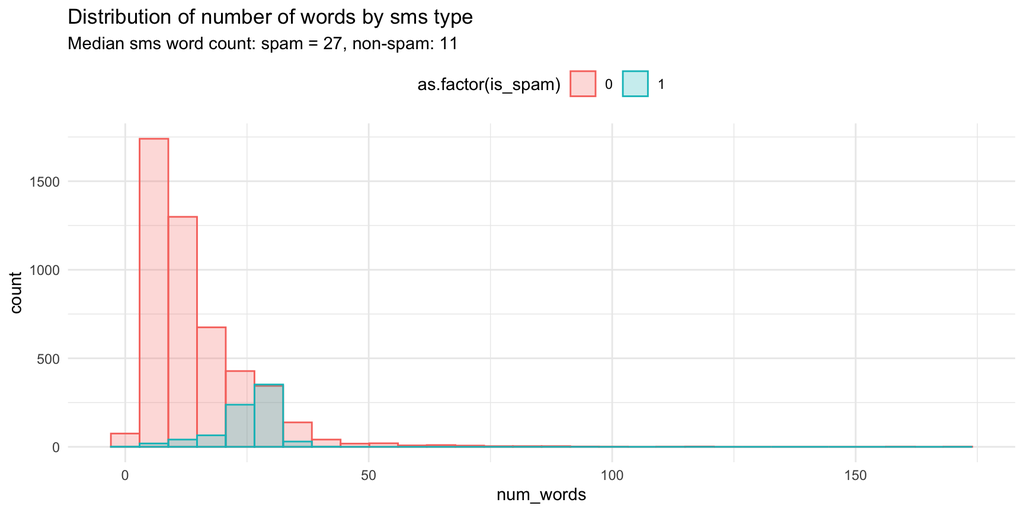

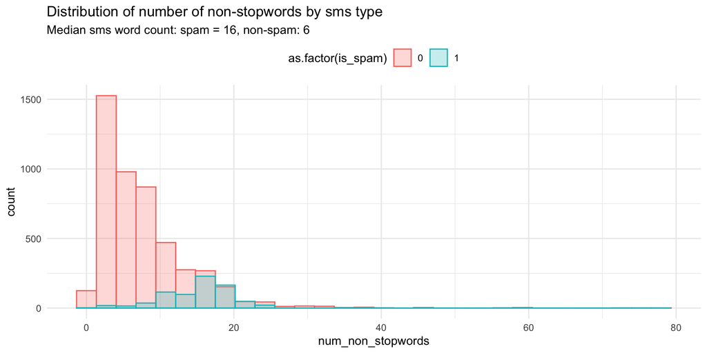

We see similar patterns like we did with length in characters: spam messages tend to be longer on average.

## Most frequent words

```r
sms_words <- merge(
    sms_words, sms[, .(message_id, is_spam)], by = "message_id"
)
```

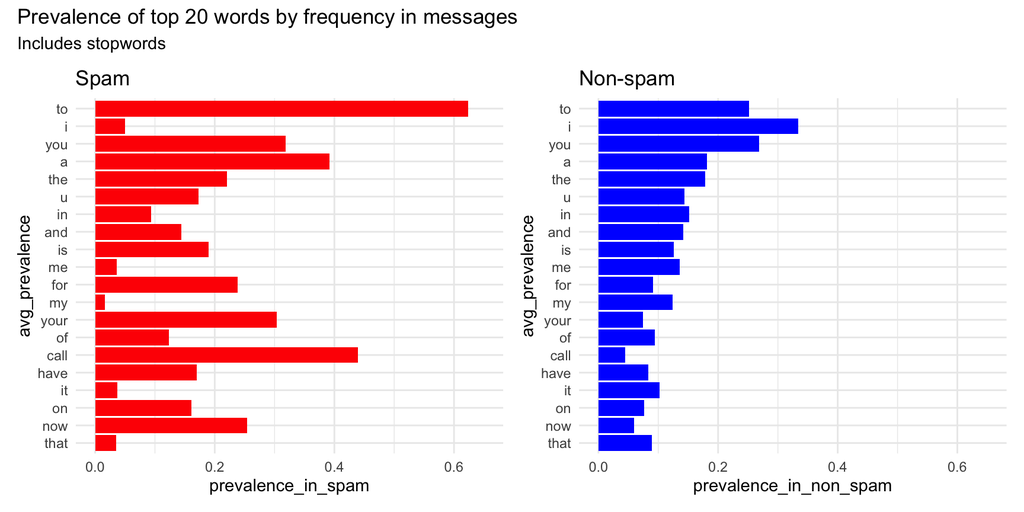

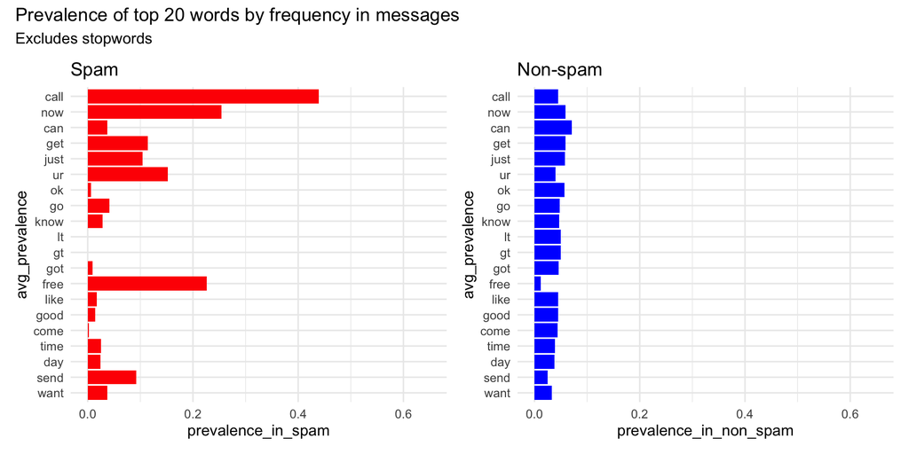

```r
num_spam_msgs <- sms_words[is_spam == 1, uniqueN(message_id)]
word_occurrences_in_spam <- sms_words[
    is_spam == 1,
    .(
        num_occurence_in_spam = uniqueN(message_id),
        prevalence_in_spam = uniqueN(message_id) / num_spam_msgs
    ),
    by = c("word", "is_stopword")
]

num_non_spam_msgs <- sms_words[is_spam == 0, uniqueN(message_id)]
word_occurrences_in_non_spam <- sms_words[
    is_spam == 0,
    .(
        num_occurence_in_non_spam = uniqueN(message_id),
        prevalence_in_non_spam = uniqueN(message_id) / num_non_spam_msgs
    ),
    by = c("word", "is_stopword")
]

word_occurrences <- merge(
    word_occurrences_in_spam, word_occurrences_in_non_spam,
    by = c("word", "is_stopword"), all = TRUE
) %>%
    .[, `:=`(
        prevalence_in_spam = dplyr::coalesce(prevalence_in_spam, 0),
        prevalence_in_non_spam = dplyr::coalesce(prevalence_in_non_spam, 0),
        num_occurence_in_spam = dplyr::coalesce(num_occurence_in_spam, 0),
        num_occurence_in_non_spam = dplyr::coalesce(num_occurence_in_non_spam, 0)
    )] %>%
    .[, num_occurance := num_occurence_in_spam + num_occurence_in_non_spam]
```

We can see that certain words (e.g. ‘free’ or ‘now’, or call-to-actions, like ‘call’ and ‘send’) appear with a much higher relative frequency is spam than in non-spam.

### Words with biggest descrepancy in their frequency

First, we’ll create a list of words which have the biggest difference in their relative frequency in spam vs non-spam sms messages:

```r
top20_diff_words <- word_occurrences %>%
    .[is_stopword == FALSE] %>%
    .[num_occurance >= 5] %>%
    .[, prevalence_diff := abs(prevalence_in_spam - prevalence_in_non_spam)] %>%
    .[order(-prevalence_diff)] %>%
    .[1:20] %>%
    .[, word]
```

Then, we’ll want to flag messages that contain those words, and do it in a format that we can feed to predictive models.

```r
all_msg_ids_w_top20_diff_words <- CJ(
    sms[, unique(message_id)], top20_diff_words
) %>%
    setnames(c("message_id", "word"))
```

This is a process we call “one-hot encoding”. For each message, we are adding a feature variable for each of the target words, which takes: + on a value of `1` if the message contains it + `0` otherwise

```r
top20_diff_words_one_hot <- merge(
    all_msg_ids_w_top20_diff_words,
    sms_words[, .(message_id, word, contains_word = 1)],
    by = c("message_id", "word"),
    all.x = TRUE
) %>%
    .[, contains_word := dplyr::coalesce(contains_word, 0)] %>%
    dcast(message_id ~ word, value.var = 'contains_word', fun.aggregate = max)
```

```r
top20_diff_words_one_hot
```

```
##       message_id 150p call cash claim contact free mobile new now prize reply
##    1:          1    0    0    0     0       0    0      0   0   0     0     0
##    2:          2    0    0    0     0       0    0      0   0   0     0     0
##    3:          3    0    0    0     0       0    1      0   0   0     0     0
##    4:          4    0    0    0     0       0    0      0   0   0     0     0
##    5:          5    0    0    0     0       0    0      0   0   0     0     0
##   ---
## 5566:       5568    0    1    0     1       1    0      0   0   0     1     0
## 5567:       5569    0    0    0     0       0    0      0   0   0     0     0
## 5568:       5570    0    0    0     0       0    0      0   0   0     0     0
## 5569:       5571    0    0    0     0       0    1      0   0   0     0     0
## 5570:       5572    0    0    0     0       0    0      0   0   0     0     0
##       send service stop text txt ur urgent win won
##    1:    0       0    0    0   0  0      0   0   0
##    2:    0       0    0    0   0  0      0   0   0
##    3:    0       0    0    1   1  0      0   1   0
##    4:    0       0    0    0   0  0      0   0   0
##    5:    0       0    0    0   0  0      0   0   0
##   ---
## 5566:    0       0    0    0   0  0      0   0   1
## 5567:    0       0    0    0   0  0      0   0   0
## 5568:    0       0    0    0   0  0      0   0   0
## 5569:    0       0    0    0   0  0      0   0   0
## 5570:    0       0    0    0   0  0      0   0   0
```

And now we add the new features to the `sms` dataset:

```r
sms <- merge(sms, top20_diff_words_one_hot, by = "message_id")
```

## Predictive modeling

### Train / test split

First, we have to separate a portion of our dataset for testing the models we create.

**EXERCISE** create an 80% train/test split!

```r
train_proportion <- 0.8

num_rows <- sms[, .N]

set.seed(20211015)
train_index <- sample(1:num_rows, floor(num_rows * train_proportion))

train <- sms[train_index]
test  <- sms[-train_index]
```

### Baseline model

Most ML project should start by establishing a useful baseline. Automatically assigning the most frequent class could be a good performance benchmark, but it is rarely useful in practice.

Rather, we will build a single-split tree model to form our baseline:

```r
baseline_model <- rpart(
    is_spam ~ sms_chr_length,
    data = train,
    control = rpart.control(maxdepth = 1)
)
baseline_model
```

```
## n= 4456
##
## node), split, n, deviance, yval
##       * denotes terminal node
##
## 1) root 4456 517.7478 0.1342011
##   2) sms_chr_length< 128.5 3415 123.2023 0.0374817 *
##   3) sms_chr_length>=128.5 1041 257.8002 0.4514890 *
```

### Evaluation of baseline model

```r
baseline_predictions <- predict(baseline_model, newdata = test)
```

Predictions will only take on two values (due to the single-split control), so we can take their avg. as our cutoff to assign classes to predicted probabilities:

```r
baseline_cutoff <- mean(unique(baseline_predictions))
```

Accuracy (remember, this is a imbalanced dataset):

```r
calculateAccuracy(test[["is_spam"]], baseline_predictions, cutoff = baseline_cutoff)
```

```
## [1] 0.8554758
```

*Note: you will find the user defined functions in `week10/eval_utils.R`.*

Better model performance metric would be AU(RO)C:

```r
baseline_auc <- calculateAUC(
    actual = test[["is_spam"]], predictions = baseline_predictions
)

baseline_auc
```

```
## [1] 0.8115902
```

Confusion matrix to visualize the TPR / FPR balance:

```r
baseline_confusion_matrix <- getConfusionMatrix(
    actual = test[["is_spam"]],
    predictions = baseline_predictions,
    cutoff = baseline_cutoff
)
```

```r
calculateFPRTPR(baseline_confusion_matrix)
```

```
##          FPR       TPR
## 1: 0.1284974 0.7516779
```

We are trading in a lot of false positives for our true positives. Hopefully, we can do better with our next models.

### Logit using only numeric features

```r
logit_only_num_feat_model <- glm(
    is_spam ~ sms_chr_length + num_words + num_non_stopwords,
    family = binomial(link = "logit"),
    data = train[, -c("message_id", "sms_text")]
)
```

```r
logit_only_num_feat_predictions <- predict(
    logit_only_num_feat_model, newdata = test, type = "response"
)
```

```r
logit_only_num_feat_auc <- calculateAUC(
    actual = test[["is_spam"]], predictions = logit_only_num_feat_predictions
)
```

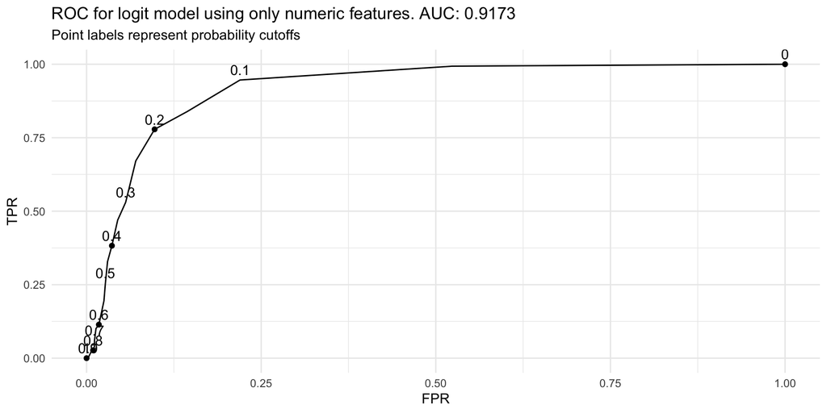

```r
calculateROC(
    actual = test[["is_spam"]], predictions = logit_only_num_feat_predictions
) %>%
    plotROC(
        model_name = "logit model using only numeric features",
        auc = logit_only_num_feat_auc
    )
```

### Logit using all features

**EXERCISE** repeat the above logit model, but now use all features (incl. the one hot encodings!)

```r
full_logit_model <- glm(
    is_spam ~ .,
    family = binomial(link = "logit"),
    data = train[, -c("message_id", "sms_text")]
)
full_logit_predictions <- predict(
    full_logit_model, newdata = test, type = "response"
)
```

```r
full_logit_auc <- calculateAUC(
    actual = test[["is_spam"]], predictions = full_logit_predictions
)
```

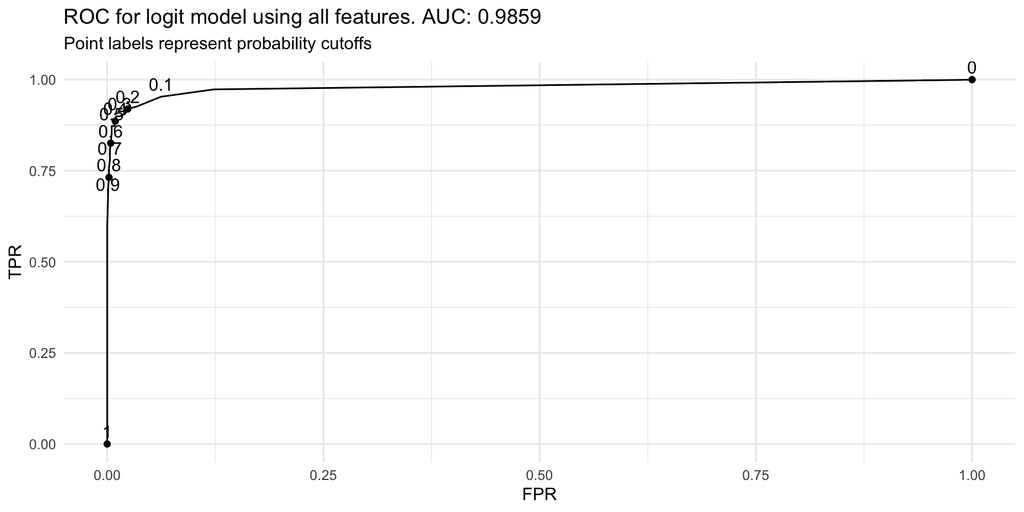

```r
calculateROC(
    actual = test[["is_spam"]],
    predictions = full_logit_predictions
) %>%
    plotROC(
        model_name = "logit model using all features",
        auc = full_logit_auc
    )
```

### Random Forest

**EXERCISE** for 2 bonus points: + repeat the full model with RF! + Also plot variable importance.